# Predicting Cervical Cancer

Joseph Hartman and Josh Sadowski

### Introduction

Within modern healthcare there is a need to utilize data from Electronic Medical Records in order to attain [meaningful use](https://www.healthit.gov/topic/meaningful-use-and-macra/meaningful-use-and-macra). More recently, healthcare practitioners are turning towards more advanced modeling techniques to lead to better insights & better patient outcomes.

The analysis conducted here will simulate this analysis by utilizing an open dataset from [UC Irvine’s Machine Learning Repository](https://archive.ics.uci.edu/ml/index.php) examining the risks for *Cervical Cancer*.

### Business Questions & Hypothsis

Within this project, we are interested in investigating multiple hypotheses and use cases.

Modeling

1. *Can the included variables be used to predict cervical cancer?*
2. *Can the included variables be used to predict a secondary risk factor, HPV?*
3. *Can we use our outcome variables as an input variable to predict other risk factors & high risk patient populations?*

Implementation

4. *Can we utilize the developed models as a detection tool for early detection tool for cervical cancer on admission?*
5. *Can we utilze our model to determine the liklihood that a patient needs a biopsy?*

### Data Acquisition, Cleaning, & Transformation

Here are the libraries we’ll need for this project

```r
library(ggplot2) #to make pretty visualizations
library(cowplot) #to put our prettty visualizations in one grid
library(GGally) #to do some correlation visualizations
```

This dataset is openly available by [clicking here](https://archive.ics.uci.edu/ml/machine-learning-databases/00383/risk_factors_cervical_cancer.csv). In this analysis we will utilize R’s built-in functions to read a URL into a CSV & then store that written object to a dataframe. To make the dataset more easily read by our models, we’ll also tell R where there are any null values.

```r
#Reading in the Data, cc for ease or naming & Cervical Cancer
cc<-read.csv(url("https://archive.ics.uci.edu/ml/machine-learning-databases/00383/risk_factors_cervical_cancer.csv"), na.strings = "?")
#Explore the top six rows to learn the data
head(cc)
```

```
  Age Number.of.sexual.partners First.sexual.intercourse Num.of.pregnancies Smokes Smokes..years. Smokes..packs.year. Hormonal.Contraceptives
1  18                         4                       15                  1      0              0                   0                       0
2  15                         1                       14                  1      0              0                   0                       0
3  34                         1                       NA                  1      0              0                   0                       0
4  52                         5                       16                  4      1             37                  37                       1
5  46                         3                       21                  4      0              0                   0                       1
6  42                         3                       23                  2      0              0                   0                       0
  Hormonal.Contraceptives..years. IUD IUD..years. STDs STDs..number. STDs.condylomatosis STDs.cervical.condylomatosis STDs.vaginal.condylomatosis
1                               0   0           0    0             0                   0                            0                           0
2                               0   0           0    0             0                   0                            0                           0
3                               0   0           0    0             0                   0                            0                           0
4                               3   0           0    0             0                   0                            0                           0
5                              15   0           0    0             0                   0                            0                           0
6                               0   0           0    0             0                   0                            0                           0
  STDs.vulvo.perineal.condylomatosis STDs.syphilis STDs.pelvic.inflammatory.disease STDs.genital.herpes STDs.molluscum.contagiosum STDs.AIDS STDs.HIV
```

[output cut: 20 more lines]

```r
#Examine the structure of the data
str(cc)
```

```
'data.frame':   858 obs. of  36 variables:
 $ Age                               : int  18 15 34 52 46 42 51 26 45 44 ...
 $ Number.of.sexual.partners         : num  4 1 1 5 3 3 3 1 1 3 ...
 $ First.sexual.intercourse          : num  15 14 NA 16 21 23 17 26 20 15 ...
 $ Num.of.pregnancies                : num  1 1 1 4 4 2 6 3 5 NA ...
 $ Smokes                            : num  0 0 0 1 0 0 1 0 0 1 ...
 $ Smokes..years.                    : num  0 0 0 37 0 ...
 $ Smokes..packs.year.               : num  0 0 0 37 0 0 3.4 0 0 2.8 ...
 $ Hormonal.Contraceptives           : num  0 0 0 1 1 0 0 1 0 0 ...
 $ Hormonal.Contraceptives..years.   : num  0 0 0 3 15 0 0 2 0 0 ...
 $ IUD                               : num  0 0 0 0 0 0 1 1 0 NA ...
 $ IUD..years.                       : num  0 0 0 0 0 0 7 7 0 NA ...
 $ STDs                              : num  0 0 0 0 0 0 0 0 0 0 ...
 $ STDs..number.                     : num  0 0 0 0 0 0 0 0 0 0 ...
 $ STDs.condylomatosis               : num  0 0 0 0 0 0 0 0 0 0 ...
```

[output cut: 22 more lines]

#### Data Dictionary

1. *Age*: Patient’s age in years
2. *Number.of.sexual.partners*: Number of sexual partners the patient has had
3. *First.sexual.intercourse*: Age in years the patient first had sexual intercourse
4. *Num.of.pregnancies*: Number of pregnancies the patient has had
5. *Smokes*: Boolean, whether or not the patient smokes
6. *Smokes..years.*: How many years the patient has smoked
7. *Smokes..packs.year.*: How many packs of cigarettes the patient smokes
8. *Hormonal.Contraceptives*: Boolean, whether or not the patient is using hormonal contraceptives like birth control pills
9. *Hormonal.Contraceptives..years.*: How long the patient has been using birth control pills
10. *IUD*: Boolean, whether or not the patient is using an IUD (intrauterine device)
11. *IUD..years.*: Number of years a patient has been using an IUD
12. *STDs*: Boolean, whether or not a patient has an STD
13. *STDs..number.*: Number of STDs a patient has
14. *STDs.condylomatosis*: Boolean, whether or not a patient has Condylomatosis
15. *STDs.cervical.condylomatosis*: Boolean, whether or not a patient has Cervical Condylomatosis
16. *STDs.vaginal.condylomatosis*:Boolean, whether or not a patient has Vaginal Condylomatosis
17. *STDs.vulvo.perineal.condylomatosis*: Boolean, whether or not a patient has Vulvo Perineal Condylomatosis
18. *STDs.syphilis*:Boolean, whether or not a patient has Syphilis
19. *STDs.pelvic.inflammatory.disease*: Boolean, whether or not a patient has Pelvic Inflammatory Disease
20. *STDs.genital.herpes*: Boolean, whether or not a patient has Genital Herpes
21. *STDs.molluscum.contagiosum*: Boolean, whether or not a patient has Molluscum Contagiosum
22. *STDs.AIDS*: Boolean, whether or not a patient has AIDS
23. *STDs.HIV*: Boolean, whether or not a patient has HIV
24. *STDs.Hepatitis.B*: Boolean, whether or not a patient has Hepatitis B
25. *STDs.HPV*: Boolean, whether or not a patient has has HPV
26. *STDs..Number.of.diagnosis*:Number of times a patient has been diagnosed with an STD
27. *STDs..Time.since.first.diagnosis*: Time since patient’s first positive diagnosis of an STD
28. *STDs..Time.since.last.diagnosis*: Time since patient’s last diagnosis of an STD
29. *Dx.Cancer*: Boolean, whether or not a patient has been diagnosed with Cancer
30. *Dx.CIN*: Boolean, whether or not a patient has been diagnosed with CIN (Cervical Intraepithelial Neoplasia)
31. *Dx.HPV*: Boolean, whether or not a patient has been diagnosed with HPV
32. *Dx*: Boolean, whether or not a patient has been diagnosed with Cervical Cancer (*I think I’m not entirely sure Josh*)
33. *Hinselmann*: Boolean, Whether or not a patient’s colonoscopy for cervical cancer tested positive *needs affirtmation*
34. *Schiller*: Boolean, Whether or not a patient’s Schiller’s test for cervical cancer tested positive *needs affirmation*
35. *Citology*: Boolean, Whether or not a patient’s citology for cervical cancer tested positive *needs affirmation*
36. *Biopsy*:Boolean, Whether or not a patient’s bioposy of cervical cells for cervical cancer tested positive *needs affirmation*

Many of the variables in the dataset are Boolean. For example, the elements of the variable `Smokes` either have the value `1` or `0` which represent `TRUE` and `FALSE` respectively if the prospective patient has ever smoked. This will be a challenge as we create our models due to the various type of data we have.

### Descriptive Statistics & Visualizations

Lets explore the first 4 variables of the dataset to get some basic demographic data and past sexual history

```r
sapply(cc[,1:4], summary, na.rm=TRUE)
```

```
$`Age`
   Min. 1st Qu.  Median    Mean 3rd Qu.    Max.
  13.00   20.00   25.00   26.82   32.00   84.00

$Number.of.sexual.partners
   Min. 1st Qu.  Median    Mean 3rd Qu.    Max.    NA's
  1.000   2.000   2.000   2.528   3.000  28.000      26

$First.sexual.intercourse
   Min. 1st Qu.  Median    Mean 3rd Qu.    Max.    NA's
     10      15      17      17      18      32       7

$Num.of.pregnancies
   Min. 1st Qu.  Median    Mean 3rd Qu.    Max.    NA's
  0.000   1.000   2.000   2.276   3.000  11.000      56
```

```
Removed 26 rows containing non-finite values (stat_bin).Removed 7 rows containing non-finite values (stat_bin).Removed 56 rows containing non-finite values (stat_bin).
```

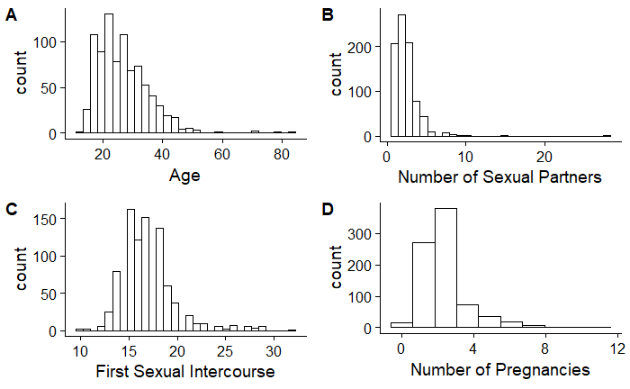

```r
plot1 <- ggplot(cc, aes(x=Age)) + geom_histogram(bins=30, color="black", fill="white")
plot2 <- ggplot(cc, aes(x=Number.of.sexual.partners)) + geom_histogram(bins=30, color="black", fill="white") + xlab("Number of Sexual Partners")
plot3 <- ggplot(cc, aes(x=First.sexual.intercourse)) + geom_histogram(bins=30, color="black", fill="white") + xlab("First Sexual Intercourse")
plot4 <- ggplot(cc, aes(x=Num.of.pregnancies)) + geom_histogram(bins=10, color="black", fill="white") + xlab("Number of Pregnancies")
plot_grid(plot1, plot2, plot3, plot4, labels = "AUTO")
```

It seems that a good deal of the participants are in the 20s-30s.

[output not shown]

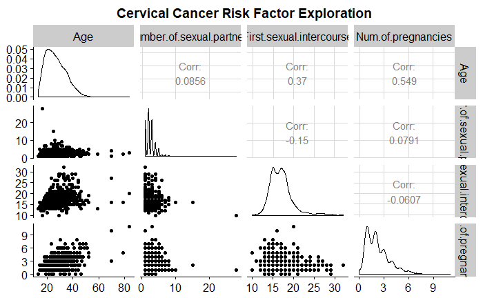

```r
ggpairs(cc,columns = 1:4,title="Cervical Cancer Risk Factor Exploration")
```

Here we can see that the strongest correlation is between the number of pregnancies a person has and how old they are. That makes sense, given that a person gets older with subsequent pregnancies.

### Modeling Techniques

To being modeling, we will be fitting basic models for understanding if we can create a predictive model to provide a risk score or likelihood of developing cervical cancer. We’ll use a Naive Bayes model often used for classification and that assumes that all predictors contribute independently towards the probability of predicting an outcome, a neural net, which uses a series of nodes much like the brain’s neurons to calculate local optima which correlate to some prediction or outcome, and a Gradient Boosted Machine, implemented through the gbm package. Gradient Boosted Machines are a tree ensemble method that were chosen for their ability to quickly implement a powerful and robust tree based algorithm used for classification and label scoring.

```r
#Load in some needed libraries
library(caret) #We will use caret for to create our stratified random sample
library(e1071) #we will use e1071 for it's naiveBayes model
library(neuralnet) #we will use the neuranet to create our neural network
library(gbm) #We will use gbm to fit our model
```

We will simplify our dataset for now, as we don’t want to use the same variables represented different ways.

```r
#Subsetting Data
cancer.1<-cc[c(1,2,5,12,29)]
#cancer.1 removing NA's for now
canc<-na.omit(cancer.1)
```

Now we will do a simple train / test split.

```r
#Set the starting state of the random number generator so it is reproducible
set.seed(100)
#Creating a stratified random sample
index<-createDataPartition(canc$Dx.Cancer,p=.8,list=FALSE)
#Creating a training dataset of .8
train.canc<-canc[index,]
#Creating a test dataset of .2
test.canc<-canc[-index,]
#Removing the outcome variable to do a proper test
test.canc.nov<-test.canc[c(1:4)]
```

Now that we have our training and testing data sets we can move on to fitting our models

Our first model will be a Naive Bayes Classifier, which uses the `naiveBayes` function from the `e1071` package. The function is relatively simple to use but we’ll implement what’s called Laplace smoothing. Laplace smoothing introduces a correction to our Naive Bayes model in the instance that a value that should be seen in our training datasset but fails to occur (maybe in our random sampling, for example, we get no observations where the patient smokes), occurs in our testing dataset. The Laplace correction pretends the value is there and adjusts it’s calculations accordingly.

```r
canc.nb <- naiveBayes(formula = as.factor(Dx.Cancer)~., #Train to optimize for status as y variable & all others as x
                      data = train.canc, #Use our training data
                      laplace = 1) #Implements Laplace smoothing
canc.nb.pred <- predict(canc.nb, test.canc.nov) #predicts values based off the variables in the testing data set
table(canc.nb.pred, test.canc$Dx.Cancer) #creates a table that compares the results of the model and the testing dataset
```

```
canc.nb.pred   0   1
           0 140   5
           1   0   0
```

```r
colnames(train.canc)
```

```
[1] "Age"                       "Number.of.sexual.partners" "Smokes"                    "STDs"                      "Dx.Cancer"
```

It seems like our Naive Bayes model correctly assumed all the negative cases, but predicted all diagnoses as negative. Suffice to say, this model isn’t very effective. Maybe one of our other models will be more effective.

Our second model is our neural network, found in the `neuralnet` package.

```r
canc.neuralnet <- neuralnet(formula = Dx.Cancer~Age + Number.of.sexual.partners + Smokes + STDs, #Train to optimize for status as y & all others as x
                            data = train.canc, #Use our training data
                            hidden = c(15,5), #How many nodes will be used
                            lifesign = "minimal", #Determines how big the output will be
                            linear.output = FALSE, #Determines if the model is non-linear or linear
                            threshold = 0.005) #Sets the error threshold as the stopping condition
```

```
hidden: 15, 5    thresh: 0.005    rep: 1/1    steps:   45467    error: 4.56943  time: 53.17 secs
```

Here’s what our neural net looks like.

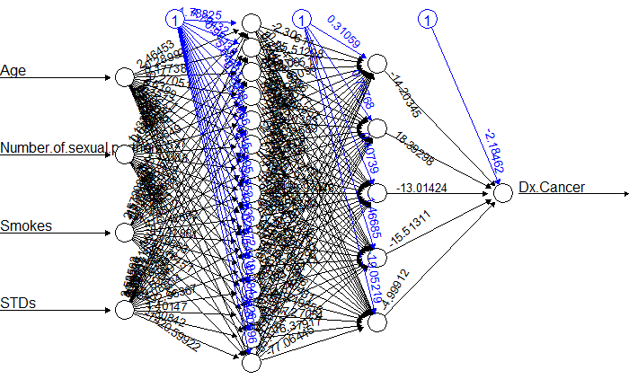

```r
plot(canc.neuralnet, rep="best") #Creates a visualization of our neural network
```

```r
canc.neuralnet.pred <- compute(canc.neuralnet, test.canc.nov) #predicts values based off the variables in the testing data set
canc.neuralnet.results <- data.frame(actual = test.canc$Dx.Cancer, prediction = round(canc.neuralnet.pred$net.result))
table(canc.neuralnet.results[,1],canc.neuralnet.results[,2])
```

```
      0
  0 140
  1   5
```

Again, we run into the problem of our model predicting all diagnoses as false. We’ll explore this further in the last section of this report.

Hopefully, our last model can do a better job.

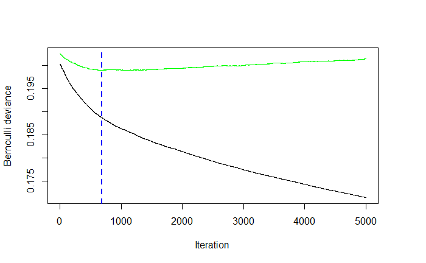

```r
#Fit Gradient Boosted Machine
set.seed(100)
canc.gbm<-gbm(train.canc$Dx.Cancer~., #Train to optimize for status as y variable & all others as x
             data=train.canc, #Use our training data
             shrinkage=0.001, #How big of a step we take during gradient descent
             distribution='bernoulli', #Binary outcome, therefore treat as bernoulli trial
             cv.folds = 5, #Resample & create 5 cross-validation folds
             n.trees=5000, #Create 5,000 trees
             verbose=FALSE) #Don't print all the things; gbm prints a lot of output otherwise
canc.gbm.model<-gbm.perf(canc.gbm,method="cv")
```

```
                                                var       rel.inf
Age                                             Age 80.4729579099
Number.of.sexual.partners Number.of.sexual.partners 19.1580053157
Smokes                                       Smokes  0.3073935598
STDs                                           STDs  0.0616432146
```

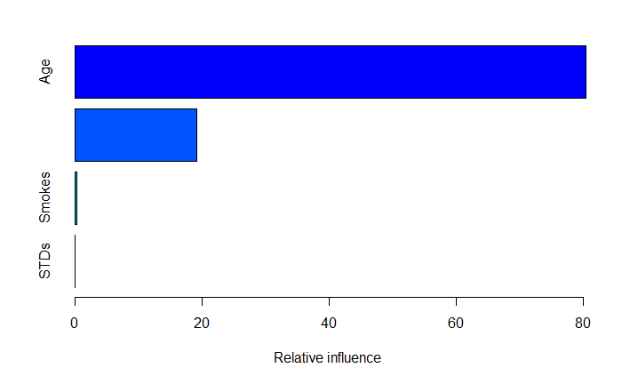

```r
summary(canc.gbm)
```

```r
canc.pred<-predict(canc.gbm,test.canc.nov,type="response") #Predictions
```

```
Using 680 trees...
```

```r
#By using type equal to "repsonse" we get a probability of cancer for each training case.
# From Greg Rideway, the GBM package author: "Predictions are on the canonical scale, which for binomial us the log-odds scale. You can use the type="response" when predicting to put it on the probability scale." <- Thanks Mr. Ridgeway!
# We then write the responses to a table; since we want to do this without "peeking" at the dataset, we do this with our test dataset that has no outcome variable included in it. Then we will write those predictions to the table that has the outcome variable & score the model.
canc.predprob.tbl<-as.data.frame(canc.pred) #Write our results to a table
scored<-cbind.data.frame(test.canc,canc.predprob.tbl) # Put those results on the training dataset
```

A few quick points:

1. AUC measures how good we did, you want it to be above .5 (random chance) & as close to 1 as possible, within reason of course - too high of an AUC means we may have a sign of overfitting.
2. For the ROC curve, we want it to be hugging the upper left-hand corner.

```r
#Model Scoring
library(pROC)
```

[output not shown]

```r
canc.auc
```

[output not shown]

### Overall Interpretation/Actionable Insights

```r
library(DescTools)
Desc(scored$Dx.Cancer, plotit = FALSE)
```

```
----------------------------------------------------------------------------------------------------------------------------------------------------
scored$Dx.Cancer (integer - dichotomous)

  length      n    NAs unique
     145    145      0      2
         100.0%   0.0%

   freq   perc  lci.95  uci.95'
0   140  96.6%   92.2%   98.5%
1     5   3.4%    1.5%    7.8%

' 95%-CI Wilson
```

We see that in our sample test population we only have 5 cases of cancer appearing. Now lets look at something within scored probabilities:

```r
max(scored$canc.pred)
```

[output not shown]

### Citations

Will need to cite the packages & their authors for:

*pROC* *ggplot2* *GGally* *gbm* *caret*